# AllLifeBank_JenniferHightower

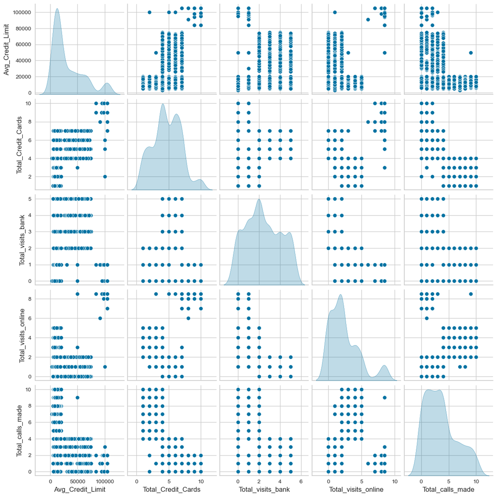

```python
num_col = data.select_dtypes(include=np.number).columns.tolist()

sns.pairplot(data=data[num_col], diag_kind="kde")
plt.show()
```

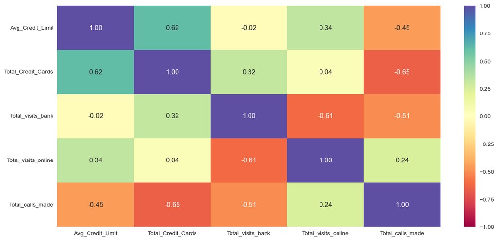

```python
corr = data[num_col].corr()

# plot the heatmap

plt.figure(figsize=(15, 7))
sns.heatmap(corr, annot=True, vmin=-1, vmax=1, fmt=".2f", cmap="Spectral")
plt.show()
```

## Observations

- It looks like The total credit cards his a positive correlation to avg credit limit
- It looks like there is a negative correlation between online visits and bank visits, which would indicate people that use the online service are not going to the physical bank and vice versa.
- There looks to aslo be a negative correlation between Total calls made and avge credit limit, total credit cards and total bank visits, which would indicate that the more calls made has some sort of negative impact on the credit limit andnumber of credit cards people have, however there is a positive correlation between total calls made and total online visits
- There seems to be little correlation between online visits and the total credit cards a customer has, however there is a positive correlation between total visits online and avg credit limit so peopel that are utilizing the online service may be using other forms of credit other than credit cards.

```python
# custDataScaled=data.apply(zscore)
# custDataScaled.head(10)

# scaling the dataset before clustering
scaler = StandardScaler()
subset = df[num_col].copy()
subset_scaled = scaler.fit_transform(subset)

# creating a dataframe of the scaled columns
custDataScaled = pd.DataFrame(subset_scaled, columns=subset.columns)
custDataScaled.head(10)
```

|  | Avg_Credit_Limit | Total_Credit_Cards | Total_visits_bank | Total_visits_online | Total_calls_made |
| --- | --- | --- | --- | --- | --- |
| 0 | 2.40 | -1.25 | -0.86 | -0.62 | -1.25 |
| 1 | 0.64 | -0.79 | -1.47 | 2.71 | 1.89 |
| 2 | 0.64 | 1.06 | -0.86 | 0.27 | 0.15 |
| 3 | -0.06 | 0.14 | -0.86 | -0.62 | 0.15 |
| 4 | 2.40 | 0.60 | -1.47 | 2.71 | -0.20 |
| 5 | -0.41 | -0.79 | -1.47 | -0.62 | 1.54 |
| 6 | 2.40 | 0.14 | -1.47 | 2.71 | -0.55 |
| 7 | -0.59 | -0.79 | -1.47 | -0.62 | -0.90 |
| 8 | -0.94 | -1.25 | -1.47 | -0.18 | -0.55 |
| 9 | -1.01 | -0.33 | -1.47 | -0.62 | 1.19 |

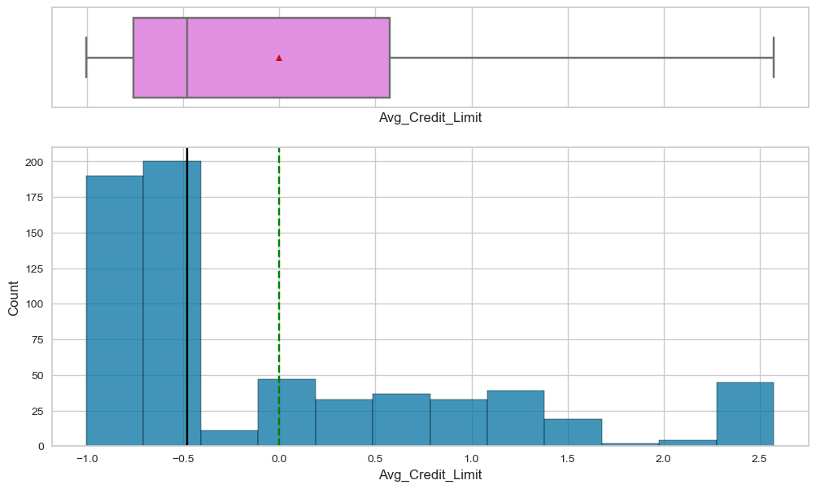

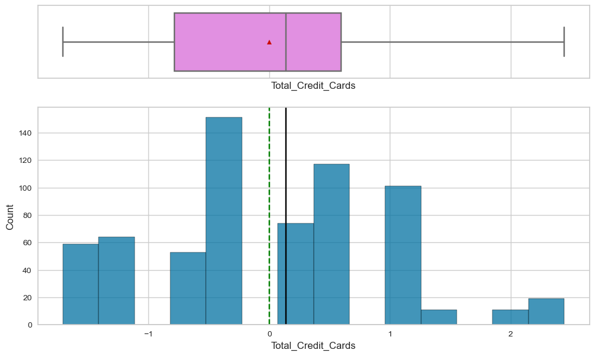

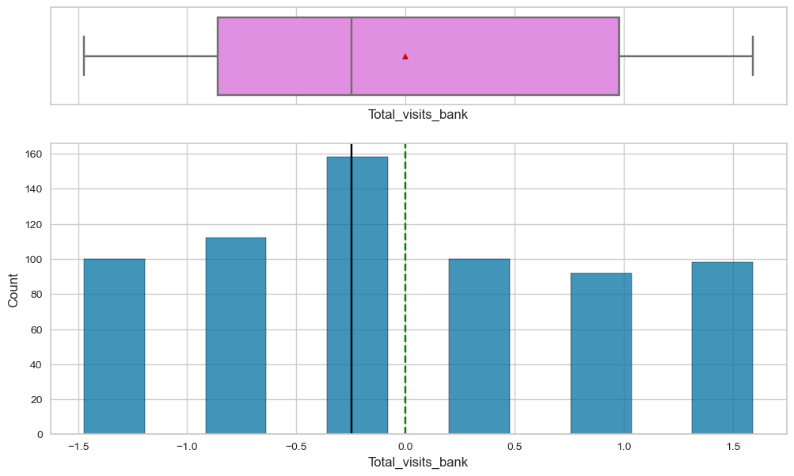

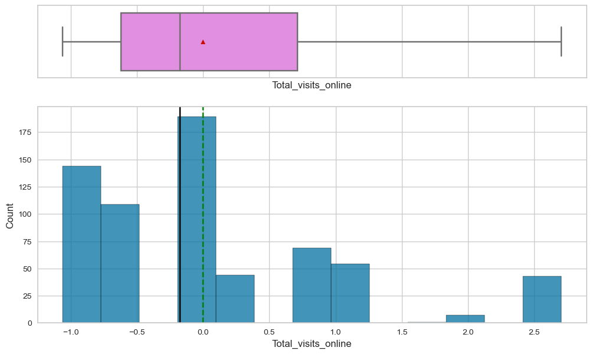

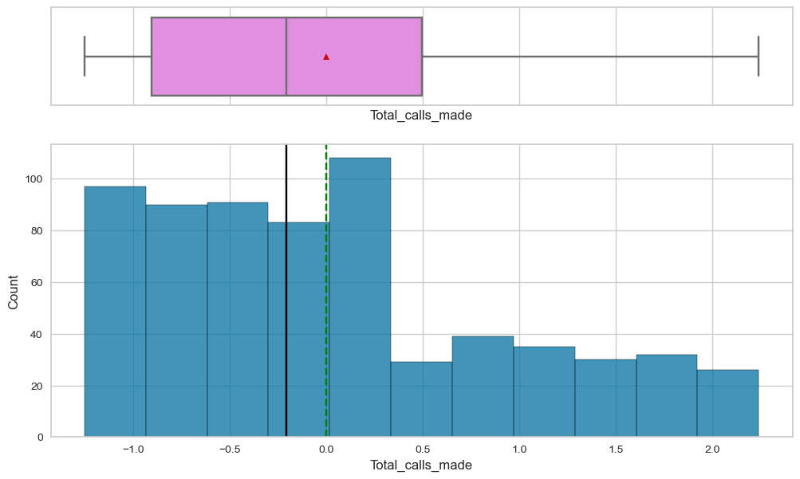

```python
for item in num_col:
    histogram_boxplot(custDataScaled, item)
```

## K Means Clustering

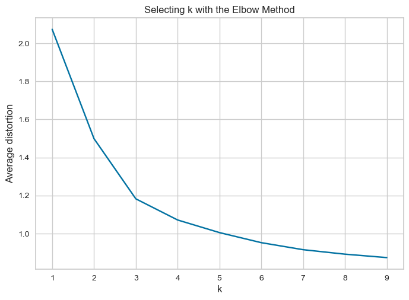

```python
#Finding optimal no. of clusters
from scipy.spatial.distance import cdist
from sklearn.cluster import KMeans

clusters=range(1,10)
meanDistortions=[]

for k in clusters:
    model=KMeans(n_clusters=k)
    model.fit(custDataScaled)
    prediction=model.predict(custDataScaled)
    meanDistortions.append(sum(np.min(cdist(custDataScaled, model.cluster_centers_, 'euclidean'), axis=1)) / custDataScaled.shape[0])


plt.plot(clusters, meanDistortions, 'bx-')
plt.xlabel('k')
plt.ylabel('Average distortion')
plt.title('Selecting k with the Elbow Method')
```

There is a definitive elbow at 3, so let's look at cluster 3 further.

```python
final_model=KMeans(3)
final_model.fit(custDataScaled)
prediction=final_model.predict(custDataScaled)

#Append the prediction
data["GROUP"] = prediction
custDataScaled["GROUP"] = prediction
print("Groups Assigned : \n")
custDataScaled.head()
```

```
Groups Assigned :
```

|  | Avg_Credit_Limit | Total_Credit_Cards | Total_visits_bank | Total_visits_online | Total_calls_made | GROUP |
| --- | --- | --- | --- | --- | --- | --- |
| 0 | 2.40 | -1.25 | -0.86 | -0.62 | -1.25 | 1 |
| 1 | 0.64 | -0.79 | -1.47 | 2.71 | 1.89 | 2 |
| 2 | 0.64 | 1.06 | -0.86 | 0.27 | 0.15 | 1 |
| 3 | -0.06 | 0.14 | -0.86 | -0.62 | 0.15 | 1 |
| 4 | 2.40 | 0.60 | -1.47 | 2.71 | -0.20 | 0 |

### Check Silhouette Scores

```
For n_clusters = 2, the silhouette score is 0.4451050499570159)
For n_clusters = 3, the silhouette score is 0.5389025466898508)
For n_clusters = 4, the silhouette score is 0.3904489560547559)
For n_clusters = 5, the silhouette score is 0.36465631472269205)
For n_clusters = 6, the silhouette score is 0.27314450116184424)
For n_clusters = 7, the silhouette score is 0.26950480124236015)
For n_clusters = 8, the silhouette score is 0.2601194016712405)
For n_clusters = 9, the silhouette score is 0.24654531759655265)
```

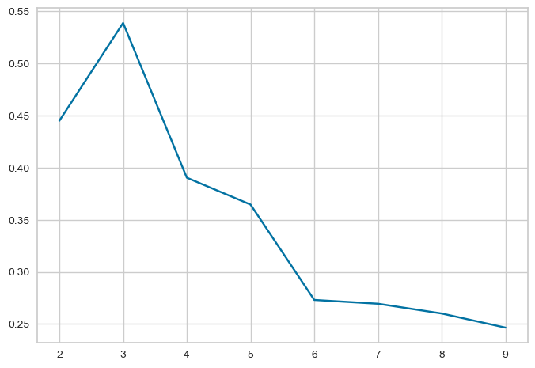

```python
from sklearn.metrics import silhouette_score

# to visualize the elbow curve and silhouette scores
from yellowbrick.cluster import KElbowVisualizer, SilhouetteVisualizer

sil_score = []
cluster_list = list(range(2, 10))
for n_clusters in cluster_list:
    clusterer = KMeans(n_clusters=n_clusters)
    preds = clusterer.fit_predict((custDataScaled))
    # centers = clusterer.cluster_centers_
    score = silhouette_score(custDataScaled, preds)
    sil_score.append(score)
    print("For n_clusters = {}, the silhouette score is {})".format(n_clusters, score))

plt.plot(cluster_list, sil_score)
plt.show()
```

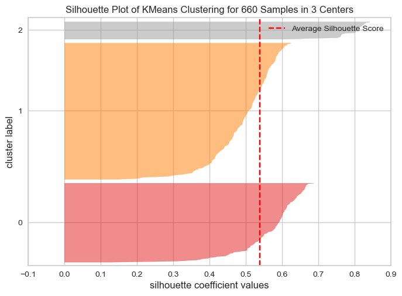

```python
# finding optimal no. of clusters with silhouette coefficients
visualizer = SilhouetteVisualizer(KMeans(3, random_state=1))
visualizer.fit(custDataScaled)
visualizer.show()
```

### Now we will analyze the distribution of the data among groups (K = 3).

```python
CusClust = data.groupby(['GROUP'])
CusClust.mean()
```

| GROUP | Avg_Credit_Limit | Total_Credit_Cards | Total_visits_bank | Total_visits_online | Total_calls_made |
| --- | --- | --- | --- | --- | --- |
| 0 | 102660.00 | 8.74 | 0.60 | 8.18 | 1.08 |
| 1 | 33782.38 | 5.52 | 3.49 | 0.98 | 2.00 |
| 2 | 12174.11 | 2.41 | 0.93 | 3.55 | 6.87 |

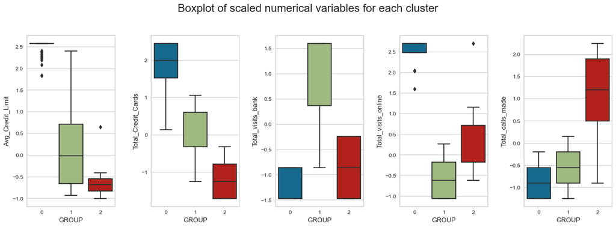

```python
# custDataScaled.boxplot(by='GROUP', layout = (2,4),figsize=(15,10))

fig, axes = plt.subplots(1, 5, figsize=(16, 6))
fig.suptitle("Boxplot of scaled numerical variables for each cluster", fontsize=20)
counter = 0
for ii in range(5):
    sns.boxplot(
        ax=axes[ii],
        y=custDataScaled[num_col[counter]],
        x=custDataScaled["GROUP"],
    )
    counter = counter + 1

fig.tight_layout(pad=2.0)
```

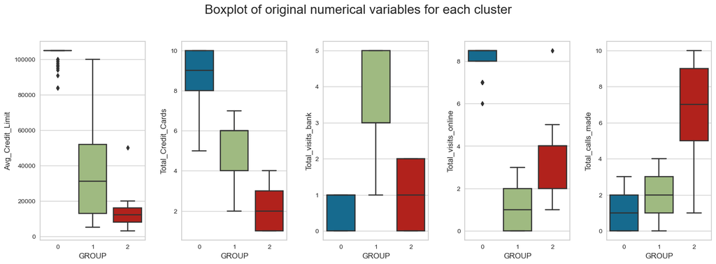

```python
fig, axes = plt.subplots(1, 5, figsize=(16, 6))
fig.suptitle("Boxplot of original numerical variables for each cluster", fontsize=20)
counter = 0
for ii in range(5):
    sns.boxplot(ax=axes[ii], y=df[num_col[counter]], x=df["GROUP"])
    counter = counter + 1

fig.tight_layout(pad=2.0)
```